# Lasso and Elastic Net

Ahlam Abuawad

7/12/2018

# Data Import and Cleaning

First, load the dataset; clean up names as needed; and convert factors to, well, factors.

```r
study_pop = read_csv("./Data/studypop.csv") %>%
  clean_names(case = c("old_janitor")) %>%
  mutate(bmi_cat3 = as.factor(bmi_cat3),
         edu_cat = as.factor(edu_cat),
         race_cat = as.factor(race_cat),
         male = as.factor(male))
```

Quick data descriptions; because of the length of the output, we don’t execute this command here, but encourage you to!

```r
describe(study_pop)
```

Next we remove missing values and reorder predictors (environmental variables first, confounders second). In keeping with standard practice, we’ll ln-transform the environmental exposures and the outcome. This is the dataset we’ll use to illustrate variable selection methods.

```r
data_lasso = study_pop %>%
  mutate_at(vars(contains("la")), log) %>%
  mutate(log_telomean = log(telomean)) %>%
  dplyr::select(log_telomean, lbx074la:lbx187la, lbxd03la:lbx194la, everything(), -seqn, -telomean) %>%
  na.omit(log_telomean)

names(data_lasso)
```

```
##  [1] "log_telomean" "lbx074la"     "lbx099la"     "lbx118la"
##  [5] "lbx138la"     "lbx153la"     "lbx170la"     "lbx180la"
##  [9] "lbx187la"     "lbxd03la"     "lbxd05la"     "lbxd07la"
## [13] "lbxf03la"     "lbxf04la"     "lbxf05la"     "lbxf08la"
## [17] "lbxpcbla"     "lbxhxcla"     "lbx194la"     "lbxwbcsi"
## [21] "lbxlypct"     "lbxmopct"     "lbxnepct"     "lbxeopct"
## [25] "lbxbapct"     "bmi_cat3"     "edu_cat"      "race_cat"
## [29] "male"         "ln_lbxcot"    "age_cent"     "age_sq"
```

```r
dim(data_lasso)
```

```
## [1] 1003   32
```

Model fitting methods aren’t “tidy-compliant” yet, so we’ll focus on creating the relevant matrices and vectors.

```r
# Create a matrix of predictors as x
x = model.matrix(log_telomean ~ ., data_lasso)[,-1]

# Extract outcome vector
y = data_lasso$log_telomean
```

Let’s take a quick look at our design matrix.

```r
dim(x)
```

```
## [1] 1003   36
```

```r
colnames(x)
```

```
##  [1] "lbx074la"  "lbx099la"  "lbx118la"  "lbx138la"  "lbx153la"
##  [6] "lbx170la"  "lbx180la"  "lbx187la"  "lbxd03la"  "lbxd05la"
## [11] "lbxd07la"  "lbxf03la"  "lbxf04la"  "lbxf05la"  "lbxf08la"
## [16] "lbxpcbla"  "lbxhxcla"  "lbx194la"  "lbxwbcsi"  "lbxlypct"
## [21] "lbxmopct"  "lbxnepct"  "lbxeopct"  "lbxbapct"  "bmi_cat32"
## [26] "bmi_cat33" "edu_cat2"  "edu_cat3"  "edu_cat4"  "race_cat2"
## [31] "race_cat3" "race_cat4" "male1"     "ln_lbxcot" "age_cent"
## [36] "age_sq"
```

```r
#View(x)
```

It’s helpful to note that chemical exposures appear in columns 1 to 18, and more traditional confounders appear in columns 19 to 36.

## Data Visualization

A few quick plots to examine associations between exposures and the outcome. First, chemical exposures:

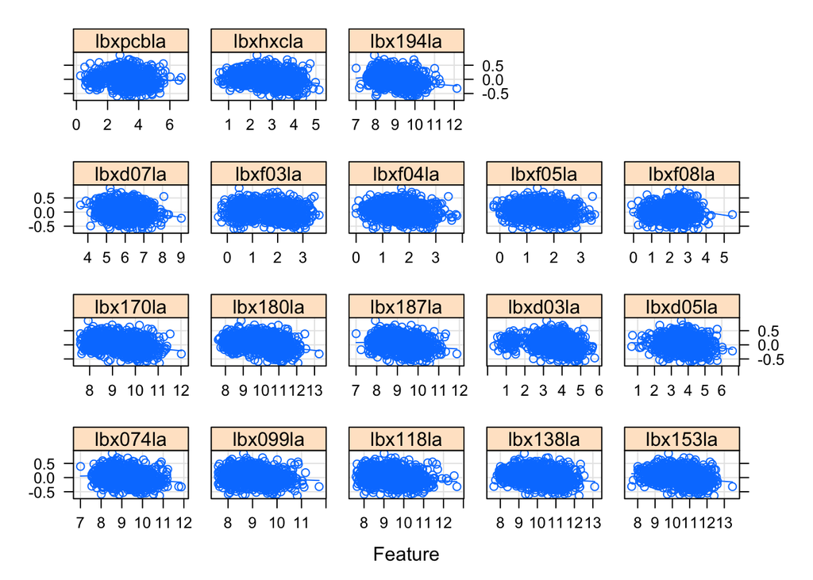

```r
# Visualize log-transformed x variables
featurePlot(x = x[,1:18],
            y = y,
            between = list(x = 1, y = 1),
            type = c("g", "p", "smooth"))
```

Next, remaining confounders:

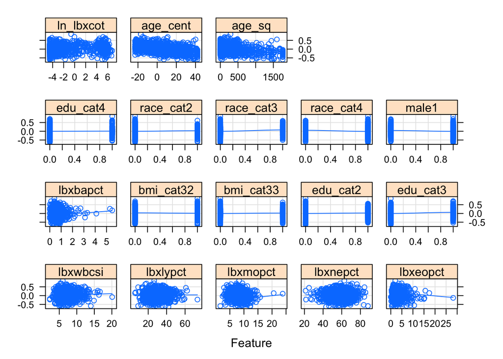

```r
# Visualize confounders
featurePlot(x = x[,19:36],
            y = y,
            between = list(x = 1, y = 1),
            type = c("g", "p", "smooth"))
```

# Lasso w/ CV

We’ll begin by looking at the lasso applied to the complete design matrix. In the following, we’ll use CV to identify tuning parameters; this is a random process, so we’ll set the seed to ensure reproducibility. First we’ll use a specified grid of tuning parameter values and fit the lasso model for each.

```r
set.seed(2)

lam_grid <- .5 ^ (-20:20)
lasso.mod = glmnet(x, y, alpha = 1, lambda = lam_grid)
```

We can explore the results using a coefficient path plot or numerically.

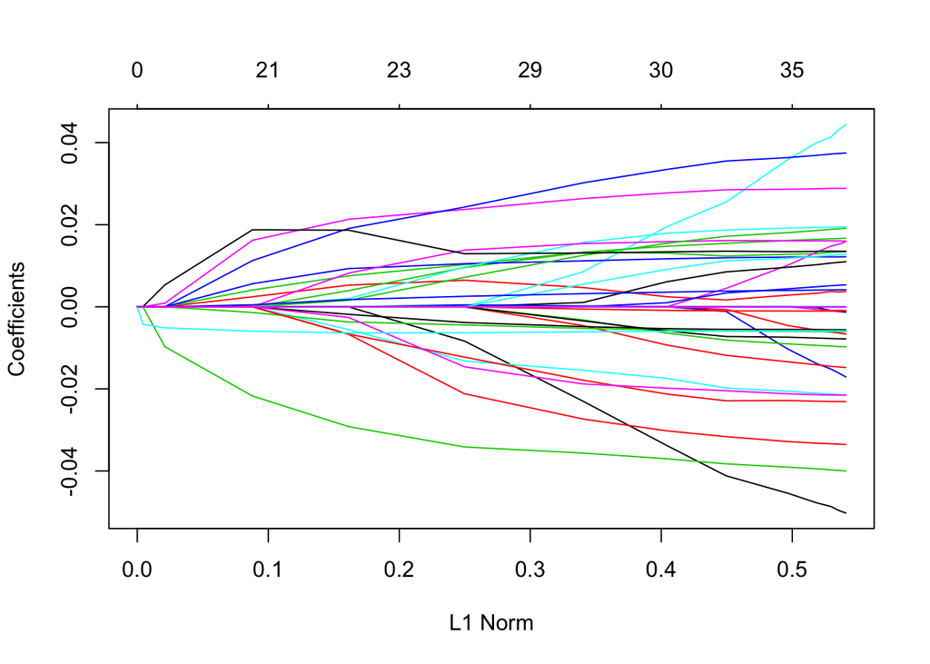

```r
plot(lasso.mod)
```

```r
coef(lasso.mod)[,10]
```

```
## (Intercept)    lbx074la    lbx099la    lbx118la    lbx138la    lbx153la
##   0.0249817   0.0000000   0.0000000   0.0000000   0.0000000   0.0000000
##    lbx170la    lbx180la    lbx187la    lbxd03la    lbxd05la    lbxd07la
##   0.0000000   0.0000000   0.0000000   0.0000000   0.0000000   0.0000000
##    lbxf03la    lbxf04la    lbxf05la    lbxf08la    lbxpcbla    lbxhxcla
##   0.0000000   0.0000000   0.0000000   0.0000000   0.0000000   0.0000000
##    lbx194la    lbxwbcsi    lbxlypct    lbxmopct    lbxnepct    lbxeopct
##   0.0000000   0.0000000   0.0000000   0.0000000   0.0000000   0.0000000
##    lbxbapct   bmi_cat32   bmi_cat33    edu_cat2    edu_cat3    edu_cat4
##   0.0000000   0.0000000   0.0000000   0.0000000   0.0000000   0.0000000
##   race_cat2   race_cat3   race_cat4       male1   ln_lbxcot    age_cent
##   0.0000000   0.0000000   0.0000000   0.0000000   0.0000000   0.0000000
##      age_sq
##   0.0000000
```

Some built-in functions will conduct a cross-validation analysis and identify the “best” tuning parameter.

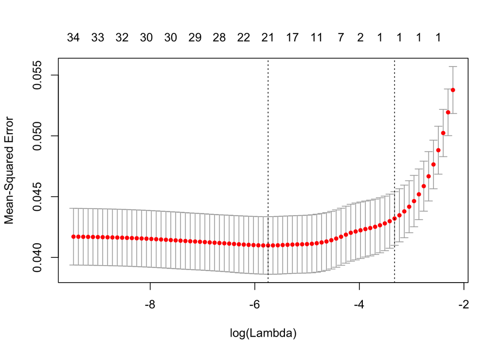

```r
# n-folds is set to a default of 10 for cv.glmnet
cv.out = cv.glmnet(x, y, alpha = 1)

plot(cv.out)
```

```r
coef(cv.out)
```

```
## 37 x 1 sparse Matrix of class "dgCMatrix"
##                        1
## (Intercept)  0.046210290
## lbx074la     .
## lbx099la     .
## lbx118la     .
## lbx138la     .
## lbx153la     .
## lbx170la     .
## lbx180la     .
## lbx187la     .
## lbxd03la     .
## lbxd05la     .
## lbxd07la     .
## lbxf03la     .
## lbxf04la     .
## lbxf05la     .
## lbxf08la     .
## lbxpcbla     .
## lbxhxcla     .
## lbx194la     .
## lbxwbcsi     .
## lbxlypct     .
## lbxmopct     .
## lbxnepct     .
## lbxeopct     .
## lbxbapct     .
## bmi_cat32    .
## bmi_cat33    .
## edu_cat2     .
## edu_cat3     .
## edu_cat4     .
## race_cat2    .
## race_cat3    .
## race_cat4    .
## male1        .
## ln_lbxcot    .
## age_cent    -0.004009845
## age_sq       .
```

```r
best_lambda = cv.out$lambda.min
best_lambda
```

```
## [1] 0.003196672
```

Optional arguments to `glmnet` can be useful – in particular, `weights` can be used in the context of the adaptive lasso and `penalty.factor` can separate penalized variables from confounders.

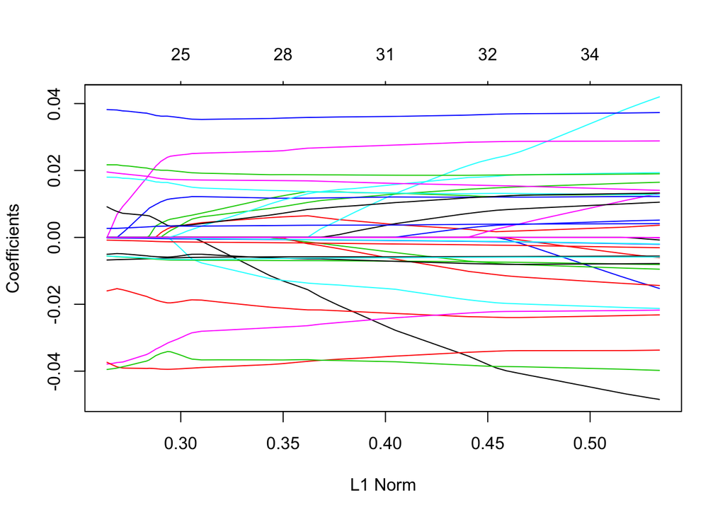

```r
is_penalized = c(rep(1, ncol(x[,1:18])), rep(0, ncol(x[,19:36])))

lasso = glmnet(x, y,
               penalty.factor = is_penalized,
               alpha = 1)
plot(lasso)
```

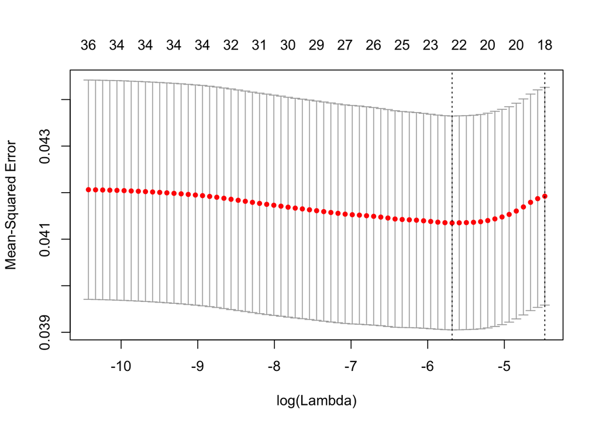

```r
# Use cross-validation (CV) to find best lambda value
cv.lasso = cv.glmnet(x, y,
                     penalty.factor = is_penalized,
                     type.measure = "mse", alpha = 1)
plot(cv.lasso)
```

```r
best_lambda = cv.lasso$lambda.min
best_lambda
```

```
## [1] 0.003408109
```

Let’s examine the model with the best CV score.

```r
# Lasso model using cross-validated lambda value
lasso.mod = glmnet(x, y,
                   penalty.factor = is_penalized,
                   alpha = 1, lambda = best_lambda)

coef_lasso = coef(lasso.mod)
coef_lasso
```

```
## 37 x 1 sparse Matrix of class "dgCMatrix"
##                        s0
## (Intercept)  1.172720e-01
## lbx074la     .
## lbx099la     1.370962e-03
## lbx118la     3.392593e-03
## lbx138la     .
## lbx153la     .
## lbx170la     .
## lbx180la     .
## lbx187la     .
## lbxd03la     .
## lbxd05la     .
## lbxd07la     .
## lbxf03la     2.202942e-02
## lbxf04la     .
## lbxf05la     .
## lbxf08la     .
## lbxpcbla     1.032126e-02
## lbxhxcla     .
## lbx194la     .
## lbxwbcsi    -6.275359e-03
## lbxlypct    -1.091354e-03
## lbxmopct    -6.418592e-03
## lbxnepct    -1.954685e-04
## lbxeopct     7.407259e-05
## lbxbapct     1.780184e-02
## bmi_cat32   -5.794979e-03
## bmi_cat33   -1.897600e-02
## edu_cat2     2.013370e-02
## edu_cat3     3.633836e-02
## edu_cat4     1.648418e-02
## race_cat2   -3.309284e-02
## race_cat3    4.953248e-03
## race_cat4   -3.938796e-02
## male1       -3.504834e-02
## ln_lbxcot    3.316291e-03
## age_cent    -6.391915e-03
## age_sq      -1.078179e-05
```

```r
# Find the number of non-zero estimates
length(coef_lasso[coef_lasso != 0]) # 23 non-zero estimates including the intercept
```

```
## <sparse>[ <logic> ] : .M.sub.i.logical() maybe inefficient
```

```
## [1] 23
```

```r
# Find variables that are non-zero
dimnames(coef_lasso)[[1]][which(coef_lasso != 0)]
```

```
##  [1] "(Intercept)" "lbx099la"    "lbx118la"    "lbxf03la"    "lbxpcbla"
##  [6] "lbxwbcsi"    "lbxlypct"    "lbxmopct"    "lbxnepct"    "lbxeopct"
## [11] "lbxbapct"    "bmi_cat32"   "bmi_cat33"   "edu_cat2"    "edu_cat3"
## [16] "edu_cat4"    "race_cat2"   "race_cat3"   "race_cat4"   "male1"
## [21] "ln_lbxcot"   "age_cent"    "age_sq"
```

```r
# Find the MSE
lasso_mse = cv.lasso$lambda.1se
lasso_mse
```

```
## [1] 0.01142263
```

The final code chunk saves the best lasso coefficients for later use.

```r
lasso_beta = cbind(rownames(coef_lasso), as.vector(coef_lasso)) %>%
  as.tibble() %>%
  rename(variable = 1, beta = 2) %>%
  mutate(beta = as.numeric(beta)) %>%
  filter(variable != "(Intercept)") %>%
  mutate(method = "Lasso")
```

# Elastic Net w/ CV

`glmnet` implements the elastic net – we’ve set `alpha` to 1 to focus on lasso regression, but could choose `alpha` between 0 and 1. In the following, we can tune alpha and lambda simultaneously.

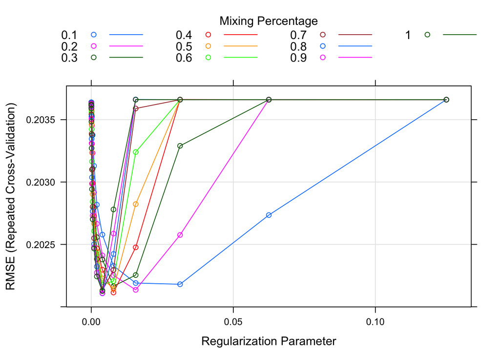

```r
# For reproducibility, set a seed
set.seed(2)

# Use CV to select best alpha value
## Create a tuning grid of alpha and lambda values
egrid <- expand.grid(alpha = (1:10) * 0.1,
                     lambda = .5^(3:20))

## Create a tuning control for cv
control <- trainControl(method = "repeatedcv",
                        repeats = 3,
                        verboseIter = TRUE)

## Use the tuning grid and control to find best alpha
elnetFit <- train(x = x,
            y = y,
            method = "glmnet",
            penalty.factor = is_penalized,
            tuneGrid = egrid,
            trControl = control)
plot(elnetFit)
```

```r
best_alpha = elnetFit$bestTune$alpha
```

For the optimal `alpha` value, we identify a best lambda and explore the results.

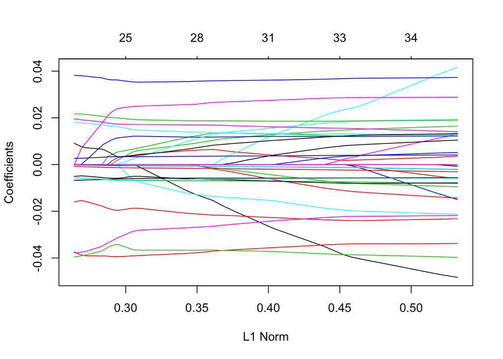

```r
elnet = glmnet(x, y,
               penalty.factor = is_penalized,
               alpha = best_alpha)
plot(elnet)
```

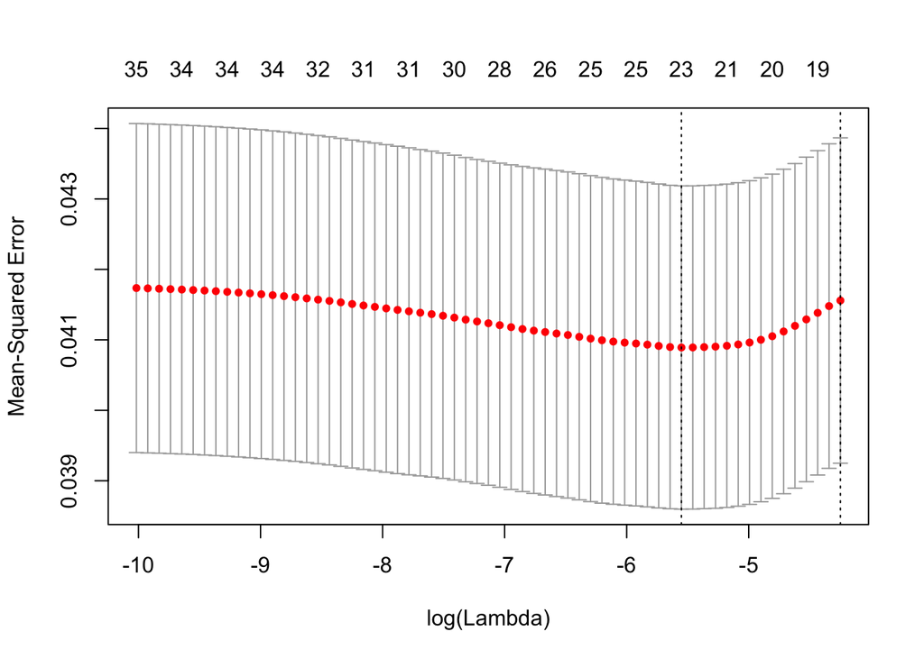

```r
# For reproducibility, set a seed
set.seed(2)

# Use CV to find best lambda value
cv.elnet = cv.glmnet(x, y,
                     penalty.factor = is_penalized,
                     type.measure = "mse", alpha = best_alpha)
plot(cv.elnet)
```

```r
best_elambda = cv.elnet$lambda.min
best_elambda
```

```
## [1] 0.003881677
```

```r
elnet.mod = glmnet(x, y,
                   penalty.factor = is_penalized,
                   alpha = best_alpha, lambda = best_elambda)

coef_elnet = coef(elnet.mod)
coef_elnet
```

```
## 37 x 1 sparse Matrix of class "dgCMatrix"
##                        s0
## (Intercept)  1.076222e-01
## lbx074la     .
## lbx099la     1.886076e-03
## lbx118la     3.867740e-03
## lbx138la     .
## lbx153la     .
## lbx170la     .
## lbx180la     .
## lbx187la     .
## lbxd03la     .
## lbxd05la     .
## lbxd07la     .
## lbxf03la     2.240200e-02
## lbxf04la     .
## lbxf05la     .
## lbxf08la     1.188894e-04
## lbxpcbla     1.057646e-02
## lbxhxcla     .
## lbx194la     .
## lbxwbcsi    -6.251747e-03
## lbxlypct    -1.099934e-03
## lbxmopct    -6.449265e-03
## lbxnepct    -2.002045e-04
## lbxeopct     7.353917e-05
## lbxbapct     1.772154e-02
## bmi_cat32   -5.826308e-03
## bmi_cat33   -1.916983e-02
## edu_cat2     2.007211e-02
## edu_cat3     3.625107e-02
## edu_cat4     1.640584e-02
## race_cat2   -3.277714e-02
## race_cat3    4.603797e-03
## race_cat4   -3.941673e-02
## male1       -3.477122e-02
## ln_lbxcot    3.336050e-03
## age_cent    -6.430194e-03
## age_sq      -1.097171e-05
```

```r
# Find the number of non-zero estimates
length(coef_elnet[coef_elnet != 0]) # 24 non-zero estimates including the intercept
```

```
## <sparse>[ <logic> ] : .M.sub.i.logical() maybe inefficient
```

```
## [1] 24
```

```r
# Find variables that are non-zero
dimnames(coef_elnet)[[1]][which(coef_elnet != 0)]
```

```
##  [1] "(Intercept)" "lbx099la"    "lbx118la"    "lbxf03la"    "lbxf08la"
##  [6] "lbxpcbla"    "lbxwbcsi"    "lbxlypct"    "lbxmopct"    "lbxnepct"
## [11] "lbxeopct"    "lbxbapct"    "bmi_cat32"   "bmi_cat33"   "edu_cat2"
## [16] "edu_cat3"    "edu_cat4"    "race_cat2"   "race_cat3"   "race_cat4"
## [21] "male1"       "ln_lbxcot"   "age_cent"    "age_sq"
```

```r
# Find the MSE
elnet_mse = cv.elnet$lambda.1se
elnet_mse
```

```
## [1] 0.01427828
```

The final code chunk saves the best lasso coefficients for later use.

```r
enet_beta <- cbind(rownames(coef_elnet), as.vector(coef_elnet)) %>%
  as.tibble() %>%
  rename(variable = 1, beta = 2) %>%
  mutate(beta = as.numeric(beta)) %>%
  filter(variable != "(Intercept)") %>%
  mutate(method = "Elastic Net")
```

# Compare Lasso and Elastic Net

```r
# Table of lambda and MSE values for lasso and elastic net
compare = cbind(as.vector(best_lambda), as.vector(lasso_mse), as.vector(best_elambda), as.vector(elnet_mse))

rownames(compare) = colnames(lasso_mse); colnames(compare) = c("Lasso Lambda", "Lasso MSE", "Elastic Lambda", "Elastic Net MSE")

knitr::kable(compare, align = "c")
```

| Lasso Lambda | Lasso MSE | Elastic Lambda | Elastic Net MSE |
| --- | --- | --- | --- |
| 0.0034081 | 0.0114226 | 0.0038817 | 0.0142783 |

```r
coef_summ = merge(enet_beta, lasso_beta, by = "variable")

ind <- rbind(enet_beta, lasso_beta)
write_csv(ind, "ind_betas.csv")
```

# OLS from Lasso Results

```r
lasso_beta = lasso_beta %>%
  filter(beta != 0) %>%
  select(term = variable, lasso = beta)

lm_from_lasso <- lm(log_telomean ~ lbx099la + lbx118la + lbxf03la +lbxpcbla +
     lbxwbcsi + lbxlypct + lbxmopct + lbxnepct + lbxeopct + lbxbapct +
     bmi_cat3 + edu_cat + race_cat + male, data = data_lasso)

ols_beta =
  lm_from_lasso %>%
  broom::tidy() %>%
  select(term, ols = estimate)

ols_v_lasso = left_join(lasso_beta, ols_beta)
ols_v_lasso
```

```
## # A tibble: 22 x 3
##    term          lasso        ols
##    <chr>         <dbl>      <dbl>
##  1 lbx099la  0.00137    0.0180
##  2 lbx118la  0.00339   -0.0783
##  3 lbxf03la  0.0220    -0.00355
##  4 lbxpcbla  0.0103     0.0198
##  5 lbxwbcsi -0.00628    0.0000914
##  6 lbxlypct -0.00109    0.00859
##  7 lbxmopct -0.00642    0.00106
##  8 lbxnepct -0.000195   0.00846
##  9 lbxeopct  0.0000741  0.00599
## 10 lbxbapct  0.0178     0.0217
## # ... with 12 more rows
```

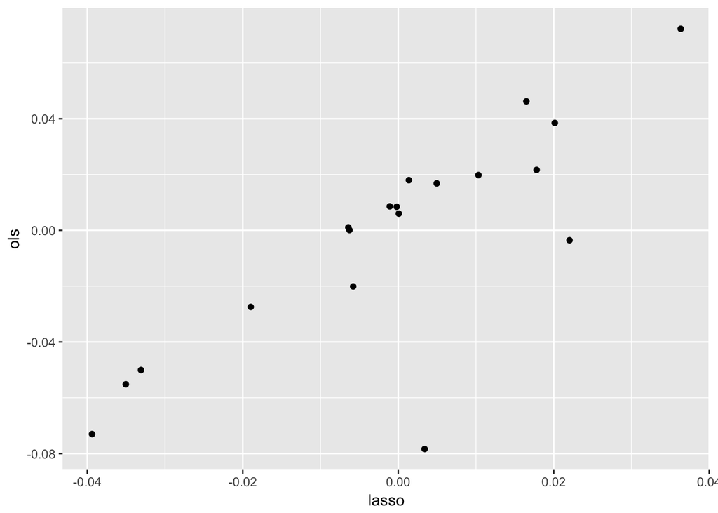

```r
ggplot(ols_v_lasso, aes(x = lasso, y = ols)) + geom_point()
```